# 5. Shared Variant Analysis

Will Hannon

4/13/2021

The goal of this notebook is to look at the iwthin host variants that are shared between crewmembers. Do any of these variants suggest that they were transmitted at low frequency between individuals? Or, are most shared variants the result of some other process - i.e. homoplasy, sequencing error, batch effect, etc..?

I’ll format the variants that I called using the pileup function of the Python library `Pysam`. I’ll also join the replicates.

Then, I’ll do the sample with the variants called with three variant calling softwares: `lofreq`, `ivar`, and `varscan`. Here, I also standardize the column names with those of the pysam variants.

```
## [1] "10027" "10114" "10028" "10138" "10039" "10107"
```

I’ll also get a list of all of the samples that have poor concordance between replicates.

```
## [1] "10088" "10089" "10091" "10117" "10136"
```

Next, I wanted to select the main variants to include in the downstream analyses. To be included, the SNPs need to meet the following criteria:

1. They must be in samples that are ‘high coverage’ 80% of the genome covered by 100 reads or more.
2. They have to be samples with high concordance between replicate allele frequencies (see `sequencing-replicate-analysis.Rmd`).
3. Variants must be present at more than 2% frequency in both of the replicates.
4. Variants must be covered by more than 100 reads in both of the replicates.

Finally, the variants are combined between the replicates by averaging the allele frequency. Then, alleles present at more than 50% frequency and less than 98% frequency are flipped to their non-consensus counterparts.

#### Shared Intrahost Variants

I wanted to see how the frequency of different variants changed throughout the boat between individuals. First, I did this with only the `pysam` variants. Most mutations are private to individuals. Some low frequency mutations are shared.

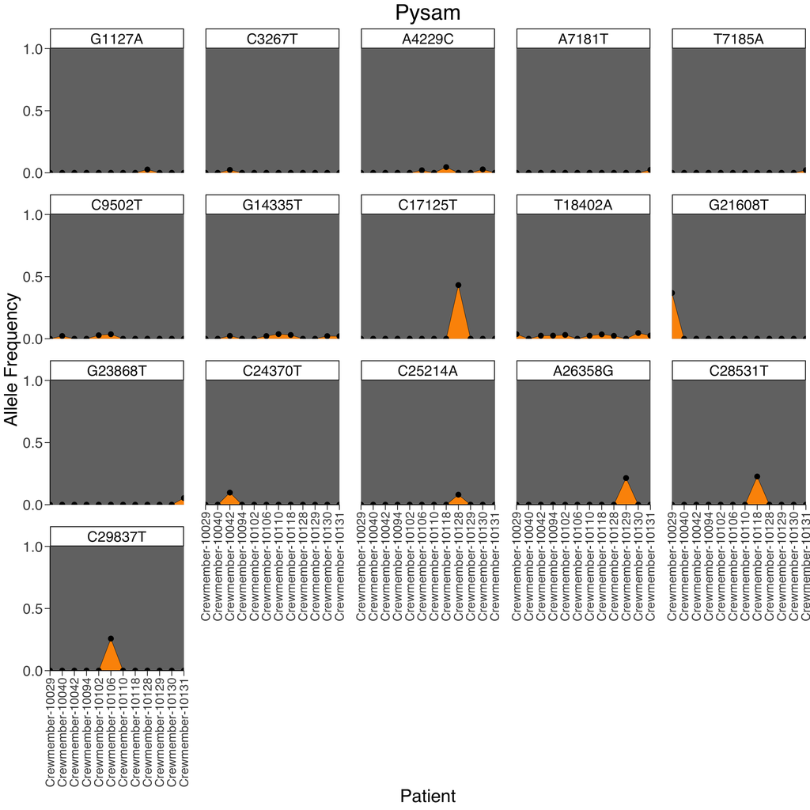

Same thing, but for `lofreq`:

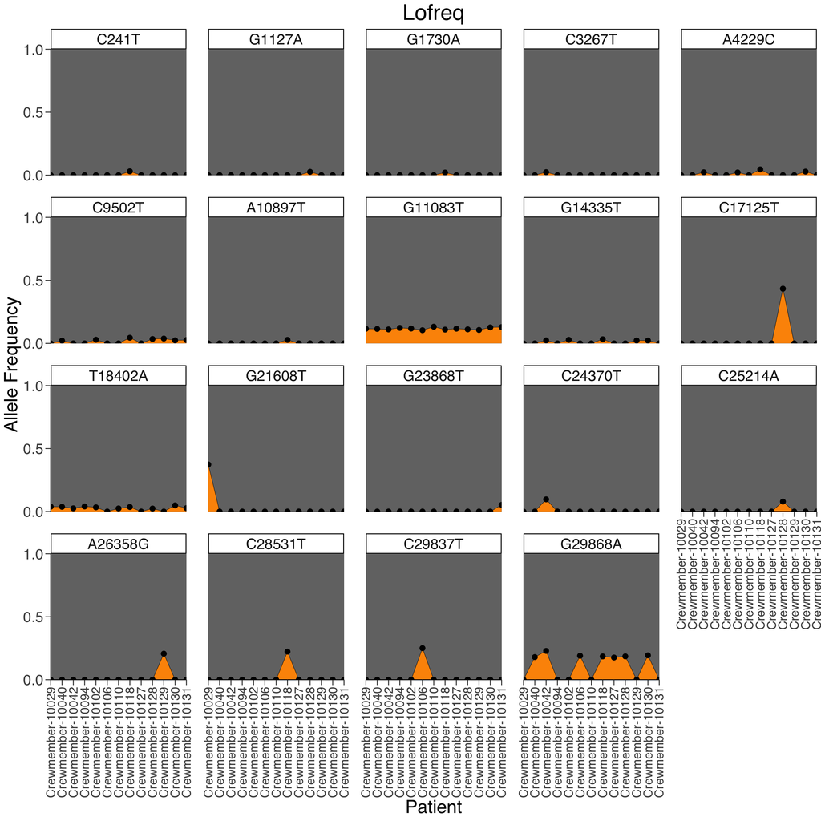

Same thing, but for `varscan`:

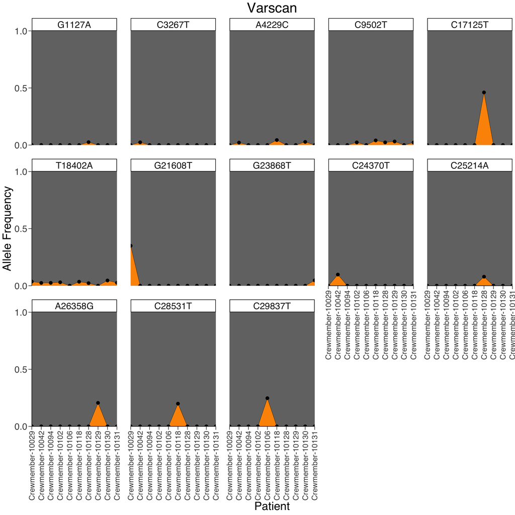

Same thing, but for `ivar`:

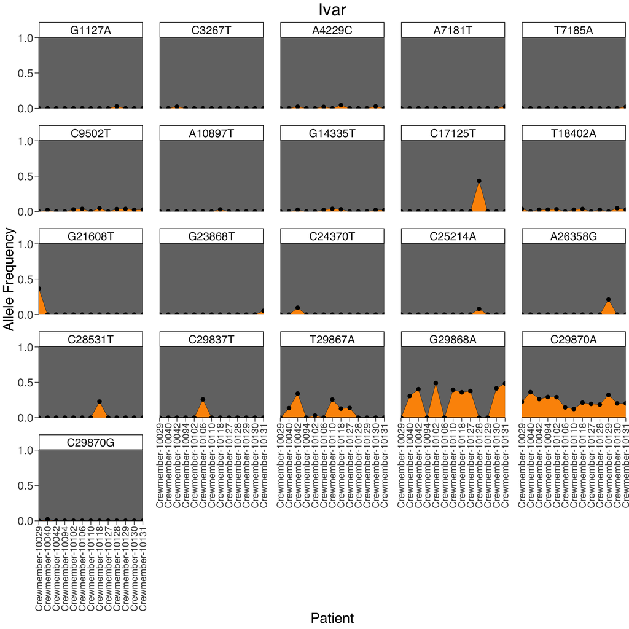

[output not shown]

The variants that show up in multiple individuals are mostly the same between the four methods. There are two key differences: (1) One site that is fixed in multiple methods shows up as a Wuhan-1 reversion in `lofreq` - 1108, (2) There are a string of mutations at the end of the genome that show up in `ivar` and `lofreq`.

#### Low Frequnecy Shared Variants

```
## [1] "Position: A4229C"
## [1] "   3/12 people have this variant."
## [1] "   Sequence Context: CCAACAG"
## [1] "   Mean Read Position Replicate 1: 9.78484576057246"
## [1] "   Mean Read Position Replicate 2: 6.90762580245379"
## [1] "   Mean Strand Ratio Replicate 1: 0.269812297381971"
## [1] "   Mean Strand Ratio Replicate 2: 0.297551738904775"
## [1] "----------------------------------------------"
## [1] "Position: C9502T"
## [1] "   3/12 people have this variant."
## [1] "   Sequence Context: TGCCTTT"
## [1] "   Mean Read Position Replicate 1: 32.8769186930091"
## [1] "   Mean Read Position Replicate 2: 30.8455071588274"
## [1] "   Mean Strand Ratio Replicate 1: 0.385460992907801"
## [1] "   Mean Strand Ratio Replicate 2: 0.501628268688636"
```

[output cut: 17 more lines]

1. `C9502T` is clearly a homopolymer region.
2. `G14335T` might be considered a homopolymeric? However, the strand bias and position bias are pretty off the charts for this variant.
3. `A4229C` is similar to above. There is a pretty clear strand/read position bias.
4. `T18402A` is passable.

Oddly, in all four cases, the base chages to the same base as its immediate neighbor.

#### Replicate Frequency differences.

This is part of the final supplementary figure showing that the freqency betweem replicates is off for these alleles.

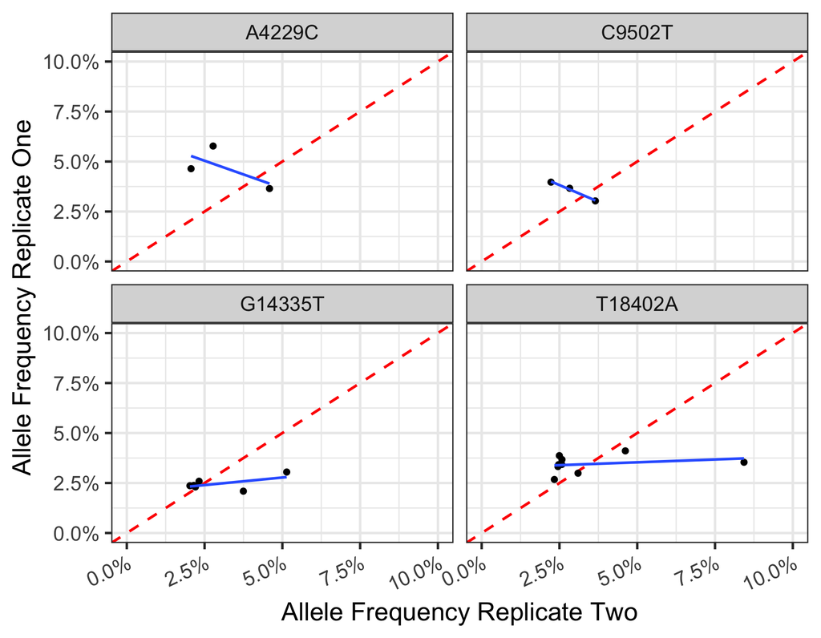

What is the “null” distributions for allele frequency correlation?

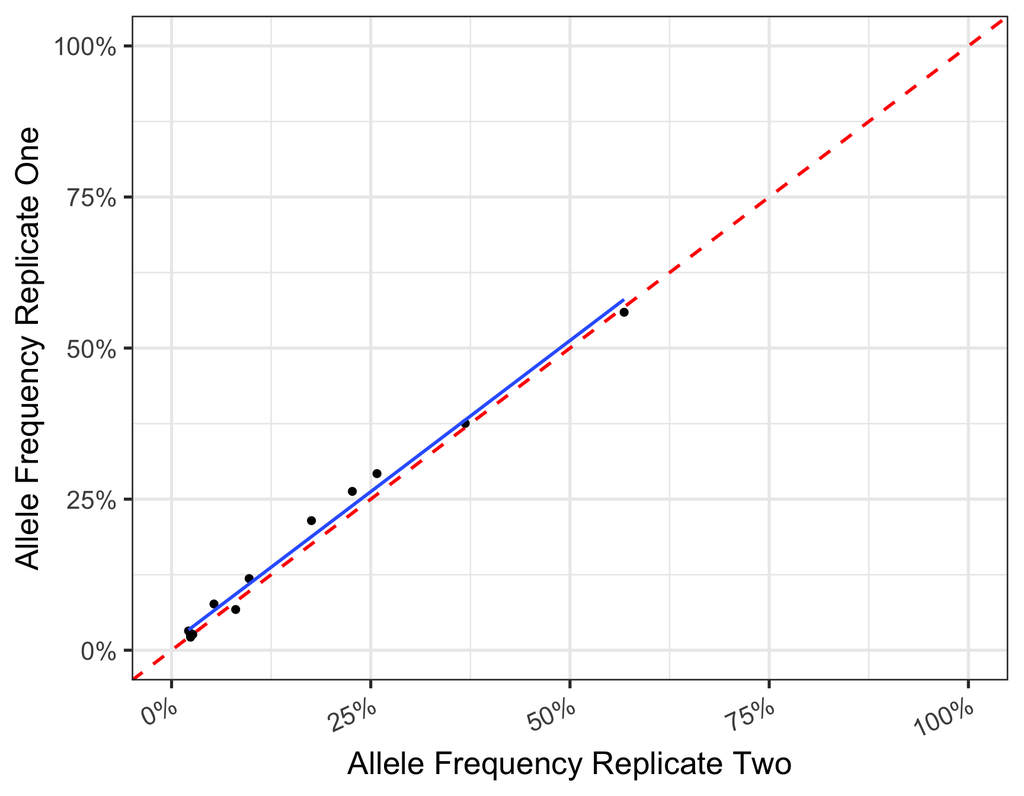